# Lab 8

Mario Perales

March 14 2016

*Source file* ⇒ lab8.Rmd

# 1

```r
vec = 1:50
i = 1

while(i < 50) {
  vec[i] <- i^2
  i <- i + 1
}
print(vec)
```

```
##  [1]    1    4    9   16   25   36   49   64   81  100  121  144  169  196
## [15]  225  256  289  324  361  400  441  484  529  576  625  676  729  784
## [29]  841  900  961 1024 1089 1156 1225 1296 1369 1444 1521 1600 1681 1764
## [43] 1849 1936 2025 2116 2209 2304 2401   50
```

This *R* code produces the same thing:

```r
vec = 1:50
for(i in 1:(length(vec)-1)) {
  vec[i] = i^2
}
print(vec)
```

```
##  [1]    1    4    9   16   25   36   49   64   81  100  121  144  169  196
## [15]  225  256  289  324  361  400  441  484  529  576  625  676  729  784
## [29]  841  900  961 1024 1089 1156 1225 1296 1369 1444 1521 1600 1681 1764
## [43] 1849 1936 2025 2116 2209 2304 2401   50
```

# 2

## a

```r
x <- seq(from = 0, to = 8, by = 2)
```

`x = 0 2 4 6 8`

## b

```r
x[x < 4] <- NA
```

`x = NA NA 4 6 8`

## c

```r
x[] <- 0
```

`x = 0 0 0 0 0`

## d

```r
x <- 0
```

`x = 0`

# 3

Fill in the appropriate types of R objects in this sentance: The lapply function in R operates on **a list** and returns **a list**.

# 4

```r
set.seed(1337)
m <- matrix(runif(15000, -3, 3), ncol = 3)
m.ssq.loop <- c(1:15000)
m.ssq.apply <- c(1:15000)
```

## a

```r
iter = 1
for(i in 1:nrow(m)) {
  for(j in 1:ncol(m)) {
    m.ssq.loop[iter] = m[i,j]^2
    iter = iter + 1
  }
}
head(m)
```

```
##            [,1]       [,2]       [,3]
## [1,]  0.4579293 -1.5301484  2.7691707
## [2,]  0.3884528  1.1452789 -1.8301459
## [3,] -2.5560586  1.3678571 -1.1991257
## [4,] -0.2768063 -2.5663416 -0.7060263
## [5,] -0.7603244 -0.5228916 -2.2818951
## [6,] -1.0120953 -2.1568870  2.9346426
```

```r
head(m.ssq.loop)
```

```
## [1] 0.2096992 2.3413542 7.6683065 0.1508955 1.3116639 3.3494342
```

## b

```r
squared_matrix <- apply(m,1:2,function(x) x^2)

iter = 1
for(i in 1:nrow(squared_matrix)) {
  for(j in 1:ncol(squared_matrix)) {
    m.ssq.apply[iter] = squared_matrix[i,j]
    iter = iter + 1
  }
}
head(m.ssq.apply)
```

```
## [1] 0.2096992 2.3413542 7.6683065 0.1508955 1.3116639 3.3494342
```

## c

```r
sanity_check <- function(x,y) {
  for(i in length(x)){
    if(x[i] != y[i]) {
      return(FALSE)
    }
  }
  return(TRUE)
}

sanity_check(m.ssq.apply,m.ssq.loop)
```

```
## [1] TRUE
```

# 5

```r
Year <- c(2000, 2001)
Algeria <- c(7 ,9)
Brazil <- c(12, NA)
Columbia <- c(16, 18)

table1 <- data.frame(Year, Algeria, Brazil, Columbia)
table1
```

```
##   Year Algeria Brazil Columbia
## 1 2000       7     12       16
## 2 2001       9     NA       18
```

```r
table2 <-
  table1 %>%
  gather(key = Country, value = Value, -Year)

table2
```

```
##   Year  Country Value
## 1 2000  Algeria     7
## 2 2001  Algeria     9
## 3 2000   Brazil    12
## 4 2001   Brazil    NA
## 5 2000 Columbia    16
## 6 2001 Columbia    18
```

```r
table3 = table1
table3$avg = c(mean(table2[Year == 2000,]$Value,na.rm = TRUE), mean(table2[Year == 2001,]$Value,na.rm = TRUE))

table3
```

```
##   Year Algeria Brazil Columbia      avg
## 1 2000       7     12       16 11.66667
## 2 2001       9     NA       18 13.50000
```

# 6

## a

The **glyphs** are cases in the CPS85 data frame which look at the `wage` and `educ` variables from the fram.

## b

The **aesthetics** are the colors **blue** and **red**, the shape of a **line** (and the corresponding line color), **circles** that correspond to the glyphs and **tick marks** to represent the x and y positions.

## c

- colors - From the variable `sex`.
- circles - A **case** from the CPS85 Data Frame
- line color - From the variable `sex`

## d

- Qualitative - `sex`
- Quantitative - `educ`, `wage`

## e

For the position aesthetic, the guides are the **tick marks** on each side of the graph. There is also a guide that tells use how the variable `sex` is mapped both to the **line color** aesthetic, as well as the **circle color** aesthetic.

## f

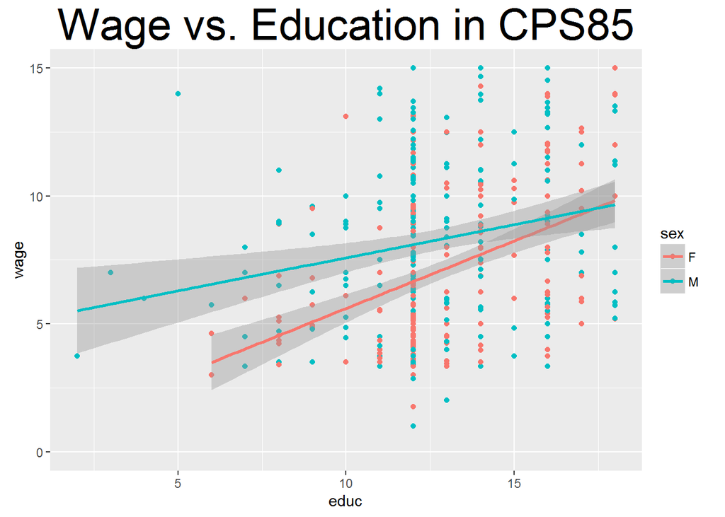

```r
CPS85 %>%
  ggplot(aes(x = educ, y = wage)) +
  geom_point(aes(color = sex)) +
  geom_smooth(method = "lm", aes(color = sex)) +
  ylim(0,15) +
  labs(title = "Wage vs. Education in CPS85") +
  theme(
    plot.title = element_text(size = 30)
  )
```

# 7

## a

```r
my.string <- "ggplot2 is a data visualization package for the statistical programming language R"

SplitChars <- function(string) {
  return(strsplit(string,"")[[1]])
}

SplitChars(my.string)
```

```
##  [1] "g" "g" "p" "l" "o" "t" "2" " " "i" "s" " " "a" " " "d" "a" "t" "a"
## [18] " " "v" "i" "s" "u" "a" "l" "i" "z" "a" "t" "i" "o" "n" " " "p" "a"
## [35] "c" "k" "a" "g" "e" " " "f" "o" "r" " " "t" "h" "e" " " "s" "t" "a"
## [52] "t" "i" "s" "t" "i" "c" "a" "l" " " "p" "r" "o" "g" "r" "a" "m" "m"
## [69] "i" "n" "g" " " "l" "a" "n" "g" "u" "a" "g" "e" " " "R"
```

## b

```r
chars <- SplitChars(my.string)

count = 0
for(i in chars) {
  if(i == "a" | i == "s" | i == "R" | i == "r") {
    count = count + 1
  }
}
count
```

```
## [1] 20
```

## c

```r
Reverse <- function(string) {
  holder_string = string
  for(i in 1:(length(string))) {
    string[i] = holder_string[length(string) - i + 1]
  }
  return(string)
}
my.string %>% SplitChars %>% Reverse
```

```
##  [1] "R" " " "e" "g" "a" "u" "g" "n" "a" "l" " " "g" "n" "i" "m" "m" "a"
## [18] "r" "g" "o" "r" "p" " " "l" "a" "c" "i" "t" "s" "i" "t" "a" "t" "s"
## [35] " " "e" "h" "t" " " "r" "o" "f" " " "e" "g" "a" "k" "c" "a" "p" " "
## [52] "n" "o" "i" "t" "a" "z" "i" "l" "a" "u" "s" "i" "v" " " "a" "t" "a"
## [69] "d" " " "a" " " "s" "i" " " "2" "t" "o" "l" "p" "g" "g"
```